# Columbia Rd: Please just build DDOT’s preferred option

2024-06-06

### What’s going on?

- After more than two years of public input, DDOT is finally revamping Columbia Rd. Construction starts next month. The project will,
  - Create dedicated bus priority lanes, so the bus is faster.
  - Create protected bike lanes along most of the road.
  - Close a section of Champlain St to cars, effectively expanding Unity Park.
- DDOT should implement this plan, because it is good!

Details of the plan: https://buspriority.ddot.dc.gov/pages/columbiardnw

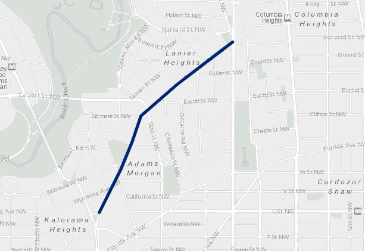

Here’s the stretch of Columbia Rd that DDOT’s improving.

### Bottom line:

- Our neighborhood has some of the lowest rates of car ownership in the entire District.
- People in our neighborhood walk, bus, metro, bike, and take public transit more than almost anywhere else in the District.
- DDOT’s plan to revamp Columbia Rd will make it safer to walk, take transit, bike, or drive.
- The plan will also make the bus faster (yay)
- The plan is obviously good and DDOT should just do it!

### Most people in our neighborhood make most trips by foot, bike, bus, and metro

- Most people walk, bike, or transit to work. We have some of the highest rates of non-car-use in the entire District.
- A huge share of us don’t even own cars (the majority along some parts of Columbia Rd).
- We live in one of the most-dense, most-transit-rich neighborhoods in all of DC.

Here’s data from the Census’ 2018-2022 American Community Survey:

[interactive chart not shown]

This was also true before COVID. Here’s the 2015-2019 Census data:

[interactive chart not shown]

Keep in mind that renters & lower-income households, who are less likely to own a car or drive, are also less likely to respond to the Census. So the maps above may be an under-estimate of walking, biking, and transit use. Census data can be found here: https://data.census.gov/table/ACSDT5Y2022.B08014?q=vehicle%20available&g=040XX00US11$1400000&y=2022&d=ACS%205-Year%20Estimates%20Detailed%20Tables&tp=true

### Too many people are injured and killed on Columbia Rd.

### DDOT’s plan makes everyone safer.

DDOT is trying to fix this street so fewer people die or are seriously injured on it each year. Road deaths remain stubbornly, unacceptably high, even after the mayor pledged to get to zero traffic deaths by 2025.

Here’s the number of injuries and deaths in ANC 1C since 2017, according to the District’s own data. Keep in mind this is likely an under-count; many of these crashes are only recorded if the police show up.

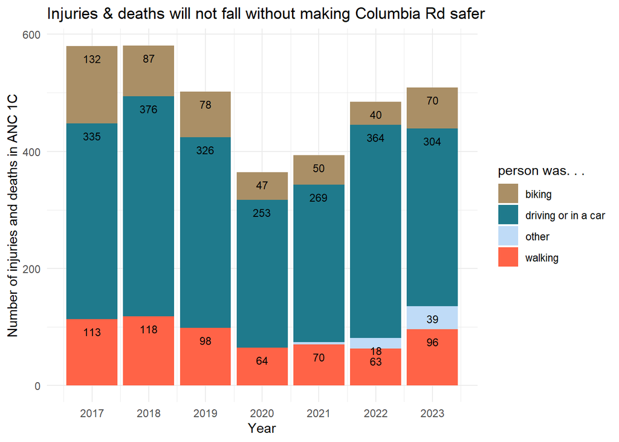

Data from Vison Zero dashboard: https://dcgis.maps.arcgis.com/apps/MapSeries/index.html?appid=d035fc78c48141b0a9770bb6cd8a3a4c

### Improving public transit can help solve DC’s air pollution problem

Finally, DC’s air quality has improved with time, but air pollution is still unacceptably high. We should be doing everything we can to encourage transit use, because personal vehicle use creates air pollution that’s bad for everyone, especially children, seniors, and people with health conditions like asthma. Auto exhaust contributes to DC’s ozone pollution problem, which led the American Lung Association to give the District an “F” rating in 2019 (https://www.nbcwashington.com/news/local/dc-arlington-failing-grade-for-air-quality-report-pollution/138556/) and a “D” rating this year (https://www.lung.org/research/sota/city-rankings/states/district-of-columbia).

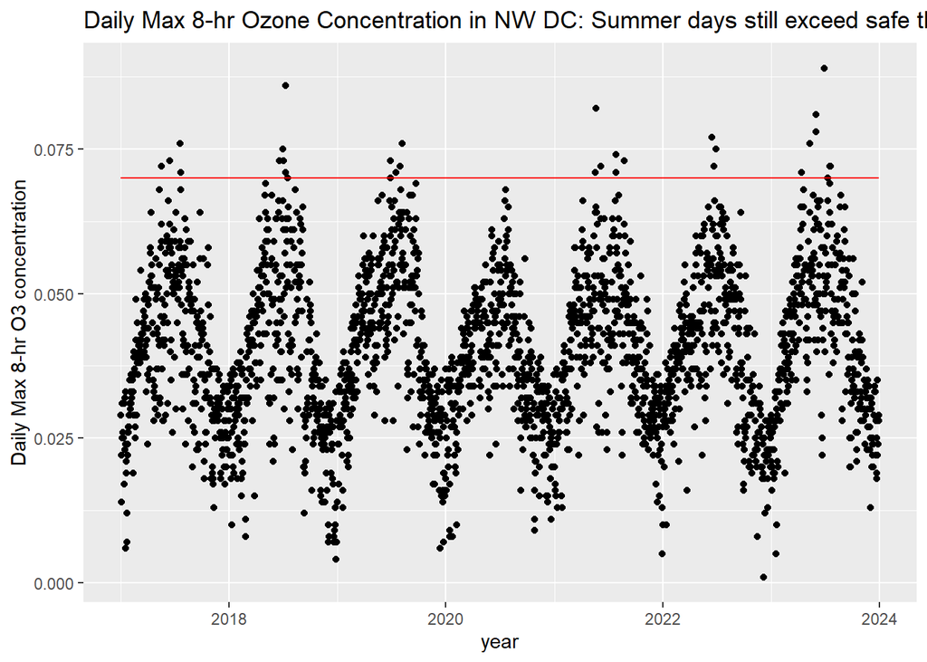

### To recap: do DDOT’s preferred plan

- Our neighborhood has some of the lowest rates of car ownership in the entire District.
- People in our neighborhood walk, bus, metro, bike, and take public transit more than almost anywhere else in the District.
- DDOT’s plan to revamp Columbia Rd will make it safer to walk, take transit, bike, or drive.
- The plan will also make the bus faster (yay)
- The plan is obviously good and DDOT should just do it.